# SBL_analysis

Steven Lawrence

September 13, 2019

# Data Retrival and Manipulation

Here I am installing all libraries neccessary for analysis

```r
install.packages(c("tidyverse","ggplot2","tseries","DataCombine","forecast","dplyr","knitr","pastecs","grid","formattable","gridExtra","viridis","viewpoint"))
```

Loading Libraries

```r
library(tidyverse)
library(ggplot2)
library(tseries)
library(DataCombine)
library(forecast)
library(dplyr)
library(knitr)
library(pastecs)
library(grid)
library(formattable)
library(gridExtra)
library(viridis)
library(magrittr)
library(qwraps2)
```

## Temporal Trend

Both temporal datasets were retrieve from trends.google.com via csv files and are depicted below showing the head and tail of each.

Head and Tail of Skin Bleaching temporal trend dataset

```
##      Time RSV
## 2 2004-01  11
## 3 2004-02  22
## 4 2004-03  39
## 5 2004-04  43
## 6 2004-05  46
## 7 2004-06  42
```

```
##        Time RSV
## 182 2019-01  42
## 183 2019-02  39
## 184 2019-03  73
## 185 2019-04  54
## 186 2019-05  44
## 187 2019-06  56
```

Head and tail of skin lightening temporal trend dataset

```
##      Time RSV
## 2 2004-01  15
## 3 2004-02  23
## 4 2004-03  15
## 5 2004-04  37
## 6 2004-05  39
## 7 2004-06  40
```

```
##        Time RSV
## 182 2019-01  64
## 183 2019-02  72
## 184 2019-03  82
## 185 2019-04  78
## 186 2019-05  78
## 187 2019-06  85
```

Here I merged the two temporal datasets to create a new variable that is the average of the two. The head and tail is shown below.

```r
## merging bleaching and lightening data temporal data sets relative search volumes by time##

SKBLT<- merge(skBT, skLT, by = "Time", sort = T)

colnames(SKBLT)<- c("Date","Bleaching", "Lightening")

#creating an average variable of bleaching and lightening temporal RSV's

SKBLT$aveRSV<- (SKBLT$Bleaching+SKBLT$Lightening)/2
#creating a subset of SKBLT only time and average RSV
SKBLT.p<- SKBLT[,c(1,4)]
head(SKBLT.p)
```

```
##      Date aveRSV
## 1 2004-01   13.0
## 2 2004-02   22.5
## 3 2004-03   27.0
## 4 2004-04   40.0
## 5 2004-05   42.5
## 6 2004-06   41.0
```

```r
tail(SKBLT.p)
```

```
##        Date aveRSV
## 181 2019-01   53.0
## 182 2019-02   55.5
## 183 2019-03   77.5
## 184 2019-04   66.0
## 185 2019-05   61.0
## 186 2019-06   70.5
```

Using the tseries and forecast package we analyazed the temporal trend.

```r
#creating a time series object in order to plot the temporal trend as a time series element
SKBLT.ts<- ts(SKBLT.p$aveRSV)
```

This plot is SBL queries by month in the United States from 2004 - 2019.

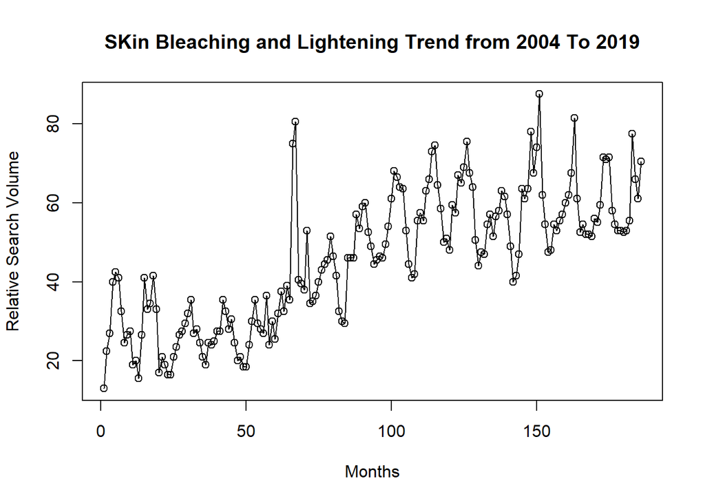

```r
#plotting sbl quries over time with a resolution of months
plot(SKBLT.ts , type = "o", main = "SKin Bleaching and Lightening Trend from 2004 To 2019", xlab = "Months", ylab = "Relative Search Volume")
```

Here I provide some discriptive statistics of the overall temporal trend.

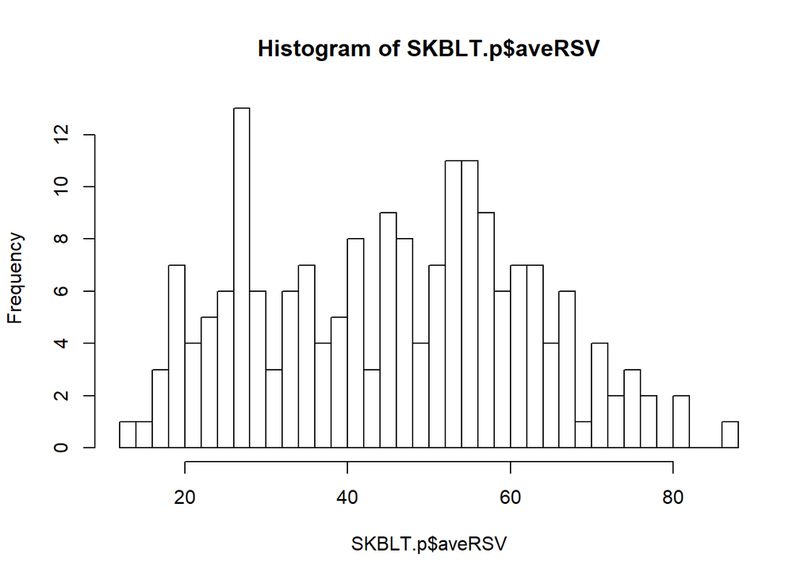

```r
hist(SKBLT.p$aveRSV, n = 40)
```

```r
mean_skbl<-mean(SKBLT.p$aveRSV)
mean_skbl
```

```
## [1] 45.77151
```

# Checking seasonality